# LineEdit

# LineEdit lets users enter text

A `LineEdit` takes input from a user’s keyboard. It can take input from a physical keyboard connected to a computer or a virtual keyboard on a mobile device.

It’s essential when the player has to name something, send chat messages, or log in to services. It pairs well with `RegEx` to match and limit text entries.

In this guide, you will learn how to:

- Set up a `LineEdit` node and use its key methods and signals.
- Let a player enter their name.
- Search through a list for items that match a search term.
- Use `RegEx` and best practices to handle email addresses and passwords.

Contents:

- LineEdit’s key features
  - Properties
  - Signals
- How to use a LineEdit in practice
  - Getting your player’s name
  - Filtering groups with a search bar
  - Authentication with email and password
- Your questions
  - How can I automatically focus on a LineEdit?
  - How can I stop a user from updating a LineEdit?

## LineEdit’s key features

### Properties

The *Placeholder Text* property helps describe what the `LineEdit` is used for before the player enters any text. Some examples are “username” or “password” for a log-in screen.

By default, placeholder text is transparent to distinguish it from the user’s input. You can change the placeholder transparency by adjusting *Placeholder -> Alpha*. `0.0` is completely transparent, while `1.0` is fully opaque.

You can customize the text cursor in the *Inspector* by setting *Caret -> Blink* to true, then adjusting its *Blink Speed*.

When you right-click on a `LineEdit`, a window will show common text shortcuts like copy and paste. You can hide this menu by disabling the *Context Menu Enabled* property.

If you don’t want users to click and drag over the text to select it, disable the *Selecting Enabled* property.

### Signals

`LineEdit` contains two key signals to let you interact with the user’s typed inputs: `text_changed` and `text_entered`. These are functionally identical, but they emit under different conditions.

`text_changed` emits every time the text changes, and `text_entered` only emits when the user hits `Enter`. Both signals include all text from the `LineEdit` in a parameter.

The `text_rejected` signal emits if the user tries to enter a character that exceeds the *Max Length*. This is handy to show the user when their input was denied, like playing an animation to shake the line edit or playing a sound.

The *Max Length* property is zero by default. When *Max Length* is zero, there is no limit on how many characters you can enter. If *Max Length* is higher than zero, it limits the number of characters you can type.

## How to use a LineEdit in practice

### Getting your player’s name

There are many cases where you want your players to name something. Some examples are save files, the player’s name, pets, and party members.

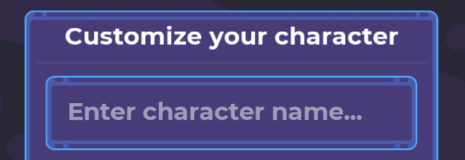

The `text_entered` signal is ideal for this kind of text entry. This signal emits when the user hits the enter key, as long as the `LineEdit` is in focus.

Emitting this way is helpful as it lets the user edit their text until they’re happy with it, and we only need to process the input at the end.

```
var character_name_regex := RegEx.new()

func _ready() -> void:
    # This regular expression helps us filter out unwanted characters. The "^"
    # inside backets mean "find all characters that are not letters or a space".
    character_name_regex.compile("[^A-Za-z ]")

    _line_edit.connect("text_changed", self, "update_player_name")


## Updates the character's name, preventing the player from entering unsupported
## characters.
func update_player_name(new_name: String) -> void:
    var caret_position = _line_edit.caret_position
    # We remove every unwanted character from the string.
    var result = character_name_regex.sub(new_name, "", true)
    _line_edit.text = result
    _name_label.text = result

    # As the function modifies the text, it may also modify the string's length,
    # causing the caret to move. So we update the caret position manually
    #
    # We need to manipulate another variable to do this. It seems the caret's
    # position updates asynchronously after changing the text.
    caret_position -= new_name.length() - result.length()
    _line_edit.caret_position = caret_position
```

The `RegEx.sub()` method stands for *substitute* and is similar to `String.replace()`. The difference here is that it scans the string for a regular expression. Here, it deletes all characters that aren’t letters or spaces. The third argument, `true`, means “don’t stop at the first match.”

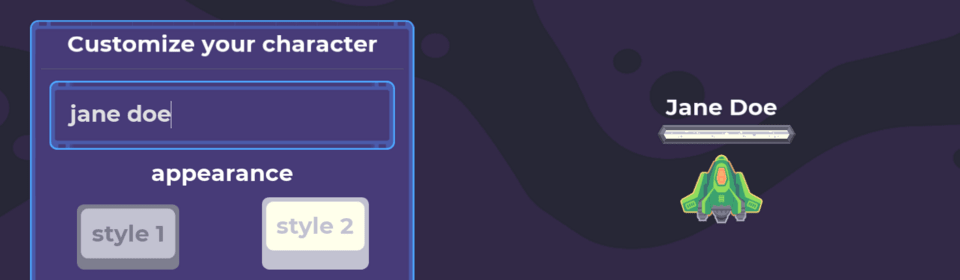

[Check out the String class reference in the Godot Docs](https://docs.godotengine.org/en/stable/classes/class_string.html) for more information on its methods to check string contents.

To learn more about using Godot’s `RegEx` object, head to the [ReGex class reference](https://docs.godotengine.org/en/stable/classes/class_regex.html).

### Filtering groups with a search bar

You may want to use `LineEdit` to search for items in a list. Filtering like this can be helpful to find specific cards in a deck-building game.

In this guide, we have a large selection of player avatars the user can choose from, using a search bar to filter them.

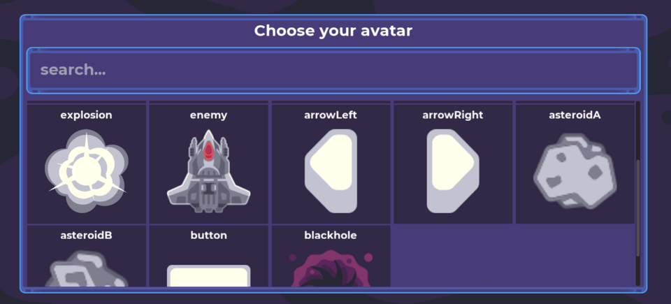

Each avatar comes from a single scene, which we named *Icon*. It contains a `Button` to handle user input, a `Label` to show its name, and a `TextureRect` to show its appearance.

A parent `ScrollContainer` lets the player navigate the `GridContainer` if it grows past its parent. The button on the icon also has a transparent `StyleBox` with a shadow around the edge. It prevents the icon or label from being obscured.

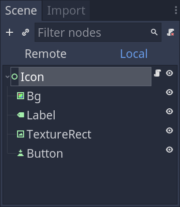

When the player types letters, we process the text on the icon’s label to determine if the entire icon should be visible or not.

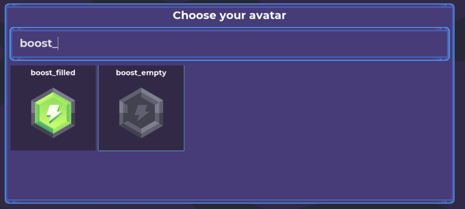

```
func update_preview(text_in: String) -> void:
    for child in _container.get_children():
        var is_search_similar := text_in.similarity(child._label.text.to_lower()) > 0.33
        var is_search_in_text := text_in.is_subsequence_of(child._label.text.to_lower())
        var is_icon_pressed: bool = child.get_pressed()

        child.visible = is_search_similar or is_search_in_text or is_icon_pressed
```

In our `LineEdit`, we take advantage of the `text_changed` signal because it emits every time the user enters a character. This lets us respond to search terms as soon as the user types them.

The `new_text` parameter reports the `LineEdit`’s current text, just like the `text_entered` signal.

If a `Control` node has *Visible* set to `false`, it will not take space in any container, including our `GridContainer`. This is why we use *Visible* to hide icons in the grid instead of moving them or fading them out. We can use code to filter which icons appear.

Using boolean logic, we can determine which items should be visible. Using the `or` statement, if any of these following conditions are true, then the icon will be visible:

1. `text_in.similarity(child._label.text.to_lower()) > 0.33`
2. `text_in.is_subsequence_of(child._label.text.to_lower())`
3. `child.get_pressed()`

If they’re all `false`, the statement will equal `false`, and the icon will hide.

Here we take advantage of two built-in string methods for filtering:

1. `similarity()` returns a value between `0.0` and `1.0` depending on how similar the two strings are. We use this to allow misspelled words in a search, also known as “fuzzy search”.
2. `is_subsequence_of()` returns true if the exact search term is in our string.

In our similarity check, `33%` is pretty generous. Higher numbers force users to be more precise, which can be helpful when searching longer words and phrases. `33%` is good for catching shorter words with a few misspelled letters.

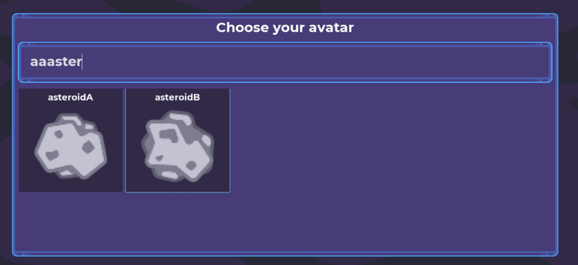

If we meet the `child.get_pressed()` condition, then we always show the selected avatar. The buttons on the icon are all in a button group, so the user can only choose one at a time. Read more about button groups in the Button tutorial.

### Authentication with email and password

Letting the player enter text to log in is essential when integrating online services, accessing user data saved on a server, and signing up to online services.

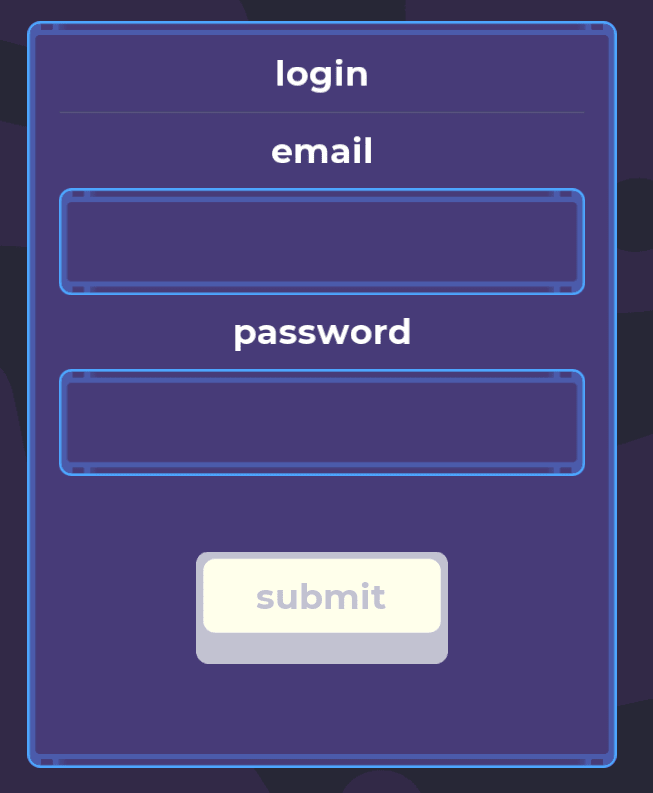

When the user opens the program, you can save them a click by grabbing the focus of the `LineEdit` as soon as it opens. In our `_ready()` function, we have the first `LineEdit` grab focus so the user can immediately start typing their email address.

```
func _ready() -> void:
    _email_line.grab_focus()
```

When handling sensitive data from users, `LineEdit` comes with some handy tools.

There is a `secret` property for fields like passwords which will print a *Special Character* instead of text. This property defaults to an asterisk: `*`.

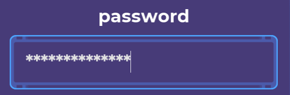

In cryptography, there is an important principle to bear in mind when handling sensitive information: password hashing.

You shouldn’t store sensitive data like passwords unprotected. There is a one-way process to make a password unreadable but still useable, using a hash.

A hash will turn some data into a series of seemingly random characters. We use a hash because one source will always give the same hash out, and a malicious actor can’t reverse the process.

If you save a hash and the user types in their password, we can hash the typed-in password and check if it is the same as our saved password. If the values are the same, we know the user entered their password correctly, without ever storing their actual password!

We can get a hash using the `md5_text()` function of a string.

```
func attempt_to_login() -> void:
    var are_credentials_good := (
        _email_line.text == email
        and _password_line.text.md5_text() == hash_pass
    )
    if are_credentials_good:
        play_login_success_animation()
```

When a user enters an email address, you may want to do some sanity checks to ensure the address is valid before sending it off. If it’s invalid, the user won’t be able to log in anyway.

For this, we can use a `RegEx` to ensure the email contains an `@` sign and dot `.` at least.

```
    email_regex.compile('.+\\@.+\\.[a-z][a-z]+')
```

To learn more about using Godot’s `RegEx` object, head to the [ReGex class reference](https://docs.godotengine.org/en/stable/classes/class_regex.html).

Now we can check if a string matches the `RegEx` pattern. We can make a function that returns true if the `LineEdit`’s text matches and `false` if it doesn’t.

```
func is_valid_email_address(email_address: String) -> bool:
    return email_regex.search(email_address) != null
```

If the validation returns `false`, we can let the user know they made a mistake when entering their email address.

```
func _on_EmailLineEdit_text_changed(new_string: String) -> void:
    var is_email_valid := not new_string.empty() and is_valid_email_address(new_string)
    var style := STYLE_FOCUS if is_email_valid else STYLE_ERROR
    _email_line.set("custom_styles/focus", style)
```

In our case, we added a few small animations to let the user know something went wrong. We update an error label to say the email address was invalid and grow the label to attract attention.

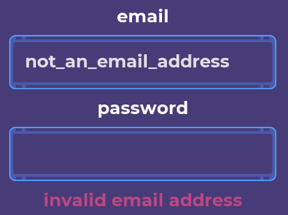

We also shake the line edit where the error occurred to clarify that this is where the error originated.

[output not shown]

Animations are vital for “game feel” and user feedback. We follow a similar process to play an animation when the user enters the right credentials as well.

## Your questions

### How can I automatically focus on a LineEdit?

It can be beneficial to focus on the `LineEdit` at specific times, for example, moving focus to a password bar after entering a username or having a window open with a `LineEdit` you want users to type into immediately.

All control nodes have built-in focus functions, and the one for this case is `grab_focus()`. This will highlight the `LineEdit` in question and let a variety of shortcuts focus on other control nodes, such as the up, down, left, and right keys and tab.

### How can I stop a user from updating a LineEdit?

`LineEdit` has a property called *Editable*. When set to `false`, the user is unable to type in new characters, and the color of the text will darken. This `Color` can be altered under `custom_colors`->`font_color_uneditable`.

With clever styling, like an empty `StyleBox`, you can use a `LineEdit` as a label for users to edit contextually. For example, you can use an uneditable `LineEdit` as a name label above a character. Then if double-clicked, make the `LineEdit` editable and have it grab focus.

In a situation like this, it is helpful to cache whatever the name used to be, so if the user enters an invalid name, you can revert it to that instead of losing the former valid name.